# Background

Using devices such as Jawbone Up, Nike FuelBand, and Fitbit it is now possible to collect a large amount of data about personal activity relatively inexpensively. These type of devices are part of the quantified self movement - a group of enthusiasts who take measurements about themselves regularly to improve their health, to find patterns in their behavior, or because they are tech geeks. One thing that people regularly do is quantify how much of a particular activity they do, but they rarely quantify how well they do it. In this project, your goal will be to use data from accelerometers on the belt, forearm, arm, and dumbell of 6 participants. They were asked to perform barbell lifts correctly and incorrectly in 5 different ways. More information is available from the website here: http://groupware.les.inf.puc-rio.br/har (see the section on the Weight Lifting Exercise Dataset).

# Data Preparation and Basic Exploratory Analysis

## 1. Import required libraries

```r
library(caret)
library(randomForest)
library(gbm)
```

```r
library(ggplot2)
library(parallel)
library(doParallel)
library(cluster)
```

## 2. Load the Data and Cleanup

```r
download.file(url = "https://d396qusza40orc.cloudfront.net/predmachlearn/pml-training.csv", destfile = "pml-training.csv")
download.file(url = "https://d396qusza40orc.cloudfront.net/predmachlearn/pml-testing.csv", destfile = "pml-testing.csv")

# Load the training and testing data set
# Replace all missing values with "NA"
pmlTraining <- read.csv("pml-training.csv", na.strings=c("NA","#DIV/0!", ""))

pmlTesting <- read.csv("pml-testing.csv", na.strings=c("NA","#DIV/0!", ""))

# Remove columns with all "NA" values
pmlTraining<-pmlTraining[,colSums(is.na(pmlTraining)) == 0]
pmlTesting <-pmlTesting[,colSums(is.na(pmlTesting)) == 0]


# Remove columns that are unnecessary for the prediction model:
colnames(pmlTraining[1:7])
```

```
## [1] "X"                    "user_name"            "raw_timestamp_part_1"
## [4] "raw_timestamp_part_2" "cvtd_timestamp"       "new_window"
## [7] "num_window"
```

```r
pmlTraining   <-pmlTraining[,-c(1:7)]
pmlTesting <-pmlTesting[,-c(1:7)]

# Remove the Near Zero Variance columns
NZV <- nearZeroVar(pmlTraining,saveMetrics=TRUE) # freqCut = 90/10,
pmlTraining <- pmlTraining[,!NZV$nzv]
pmlTesting <- pmlTesting[,!NZV$nzv]
```

## 3. Summarize the Data

```r
# Show the data structure after the transforms
str(pmlTraining)
```

```
## 'data.frame':    19622 obs. of  53 variables:
##  $ roll_belt           : num  1.41 1.41 1.42 1.48 1.48 1.45 1.42 1.42 1.43 1.45 ...
##  $ pitch_belt          : num  8.07 8.07 8.07 8.05 8.07 8.06 8.09 8.13 8.16 8.17 ...
##  $ yaw_belt            : num  -94.4 -94.4 -94.4 -94.4 -94.4 -94.4 -94.4 -94.4 -94.4 -94.4 ...
##  $ total_accel_belt    : int  3 3 3 3 3 3 3 3 3 3 ...
##  $ gyros_belt_x        : num  0 0.02 0 0.02 0.02 0.02 0.02 0.02 0.02 0.03 ...
##  $ gyros_belt_y        : num  0 0 0 0 0.02 0 0 0 0 0 ...
##  $ gyros_belt_z        : num  -0.02 -0.02 -0.02 -0.03 -0.02 -0.02 -0.02 -0.02 -0.02 0 ...
##  $ accel_belt_x        : int  -21 -22 -20 -22 -21 -21 -22 -22 -20 -21 ...
##  $ accel_belt_y        : int  4 4 5 3 2 4 3 4 2 4 ...
##  $ accel_belt_z        : int  22 22 23 21 24 21 21 21 24 22 ...
##  $ magnet_belt_x       : int  -3 -7 -2 -6 -6 0 -4 -2 1 -3 ...
##  $ magnet_belt_y       : int  599 608 600 604 600 603 599 603 602 609 ...
##  $ magnet_belt_z       : int  -313 -311 -305 -310 -302 -312 -311 -313 -312 -308 ...
##  $ roll_arm            : num  -128 -128 -128 -128 -128 -128 -128 -128 -128 -128 ...
```

[output cut: 39 more lines]

```r
# Summarize the data
summary(pmlTraining)
```

```
##    roll_belt        pitch_belt          yaw_belt       total_accel_belt
##  Min.   :-28.90   Min.   :-55.8000   Min.   :-180.00   Min.   : 0.00
##  1st Qu.:  1.10   1st Qu.:  1.7600   1st Qu.: -88.30   1st Qu.: 3.00
##  Median :113.00   Median :  5.2800   Median : -13.00   Median :17.00
##  Mean   : 64.41   Mean   :  0.3053   Mean   : -11.21   Mean   :11.31
##  3rd Qu.:123.00   3rd Qu.: 14.9000   3rd Qu.:  12.90   3rd Qu.:18.00
##  Max.   :162.00   Max.   : 60.3000   Max.   : 179.00   Max.   :29.00
##   gyros_belt_x        gyros_belt_y       gyros_belt_z
##  Min.   :-1.040000   Min.   :-0.64000   Min.   :-1.4600
##  1st Qu.:-0.030000   1st Qu.: 0.00000   1st Qu.:-0.2000
##  Median : 0.030000   Median : 0.02000   Median :-0.1000
##  Mean   :-0.005592   Mean   : 0.03959   Mean   :-0.1305
##  3rd Qu.: 0.110000   3rd Qu.: 0.11000   3rd Qu.:-0.0200
##  Max.   : 2.220000   Max.   : 0.64000   Max.   : 1.6200
##   accel_belt_x       accel_belt_y     accel_belt_z     magnet_belt_x
##  Min.   :-120.000   Min.   :-69.00   Min.   :-275.00   Min.   :-52.0
##  1st Qu.: -21.000   1st Qu.:  3.00   1st Qu.:-162.00   1st Qu.:  9.0
##  Median : -15.000   Median : 35.00   Median :-152.00   Median : 35.0
##  Mean   :  -5.595   Mean   : 30.15   Mean   : -72.59   Mean   : 55.6
##  3rd Qu.:  -5.000   3rd Qu.: 61.00   3rd Qu.:  27.00   3rd Qu.: 59.0
##  Max.   :  85.000   Max.   :164.00   Max.   : 105.00   Max.   :485.0
##  magnet_belt_y   magnet_belt_z       roll_arm         pitch_arm
##  Min.   :354.0   Min.   :-623.0   Min.   :-180.00   Min.   :-88.800
##  1st Qu.:581.0   1st Qu.:-375.0   1st Qu.: -31.77   1st Qu.:-25.900
##  Median :601.0   Median :-320.0   Median :   0.00   Median :  0.000
##  Mean   :593.7   Mean   :-345.5   Mean   :  17.83   Mean   : -4.612
##  3rd Qu.:610.0   3rd Qu.:-306.0   3rd Qu.:  77.30   3rd Qu.: 11.200
##  Max.   :673.0   Max.   : 293.0   Max.   : 180.00   Max.   : 88.500
##     yaw_arm          total_accel_arm  gyros_arm_x        gyros_arm_y
##  Min.   :-180.0000   Min.   : 1.00   Min.   :-6.37000   Min.   :-3.4400
##  1st Qu.: -43.1000   1st Qu.:17.00   1st Qu.:-1.33000   1st Qu.:-0.8000
##  Median :   0.0000   Median :27.00   Median : 0.08000   Median :-0.2400
##  Mean   :  -0.6188   Mean   :25.51   Mean   : 0.04277   Mean   :-0.2571
##  3rd Qu.:  45.8750   3rd Qu.:33.00   3rd Qu.: 1.57000   3rd Qu.: 0.1400
##  Max.   : 180.0000   Max.   :66.00   Max.   : 4.87000   Max.   : 2.8400
##   gyros_arm_z       accel_arm_x       accel_arm_y      accel_arm_z
##  Min.   :-2.3300   Min.   :-404.00   Min.   :-318.0   Min.   :-636.00
##  1st Qu.:-0.0700   1st Qu.:-242.00   1st Qu.: -54.0   1st Qu.:-143.00
##  Median : 0.2300   Median : -44.00   Median :  14.0   Median : -47.00
##  Mean   : 0.2695   Mean   : -60.24   Mean   :  32.6   Mean   : -71.25
```

[output cut: 50 more lines]

```
##  Max.   :311.00000   Max.   :231.0000   Max.   : 477.00   Max.   : 923.0
##  accel_forearm_z   magnet_forearm_x  magnet_forearm_y magnet_forearm_z
##  Min.   :-446.00   Min.   :-1280.0   Min.   :-896.0   Min.   :-973.0
##  1st Qu.:-182.00   1st Qu.: -616.0   1st Qu.:   2.0   1st Qu.: 191.0
##  Median : -39.00   Median : -378.0   Median : 591.0   Median : 511.0
##  Mean   : -55.29   Mean   : -312.6   Mean   : 380.1   Mean   : 393.6
##  3rd Qu.:  26.00   3rd Qu.:  -73.0   3rd Qu.: 737.0   3rd Qu.: 653.0
##  Max.   : 291.00   Max.   :  672.0   Max.   :1480.0   Max.   :1090.0
##  classe
##  A:5580
##  B:3797
##  C:3422
##  D:3216
##  E:3607
##
```

## 4. Cross-Validation Partitioning

```r
# Set the seed for data reproducability
set.seed(9876)

# Partition the data into 75% training and 25% testing sets
# using random subsampling without replacement
inTrain <- createDataPartition(y=pmlTraining$classe, p=0.75, list=FALSE)
trainData <- as.data.frame(pmlTraining[inTrain,])
testData <- as.data.frame(pmlTraining[-inTrain,])
dim(trainData)
```

```
## [1] 14718    53
```

```r
dim(testData)
```

```
## [1] 4904   53
```

# Modeling

## 5. Train the data using the Random Forest classifier model and Boosting

### Random Forest

```r
# After painstakingly battling Windows and my laptop with limited memory and processors,
# I found the ability to parallel process the random forest model in the
# train function here: (https://github.com/lgreski/datasciencectacontent/blob/master/markdown/pml-randomForestPerformance.md)
# Detect number of cores and subtract 1 to avoid crashing your machine by keeping
# your operating system functional
cluster <- makeCluster(detectCores() - 1)
registerDoParallel(cluster)

# Set the train control to k-fold cross-validation and set the number of the quantity
# of folds.
ctrl <- trainControl(method="cv", number=5, allowParallel=TRUE)

# Examine all variables in the trainData set to predict the classe variable
pmlRF <- train(classe ~ ., data = trainData, method = "rf", trControl=ctrl)

# Predict
RFPred <- predict(pmlRF, testData)

# Use the testData set to test the results
confusionMatrix(RFPred, testData$classe)
```

```
## Confusion Matrix and Statistics
##
##           Reference
## Prediction    A    B    C    D    E
##          A 1393    4    0    0    0
##          B    1  945    5    0    0
##          C    1    0  847    6    1
##          D    0    0    3  798    1
##          E    0    0    0    0  899
##
## Overall Statistics
##
##                Accuracy : 0.9955
##                  95% CI : (0.9932, 0.9972)
##     No Information Rate : 0.2845
##     P-Value [Acc > NIR] : < 2.2e-16
##
##                   Kappa : 0.9943
##  Mcnemar's Test P-Value : NA
##
## Statistics by Class:
##
##                      Class: A Class: B Class: C Class: D Class: E
## Sensitivity            0.9986   0.9958   0.9906   0.9925   0.9978
## Specificity            0.9989   0.9985   0.9980   0.9990   1.0000
## Pos Pred Value         0.9971   0.9937   0.9906   0.9950   1.0000
## Neg Pred Value         0.9994   0.9990   0.9980   0.9985   0.9995
## Prevalence             0.2845   0.1935   0.1743   0.1639   0.1837
## Detection Rate         0.2841   0.1927   0.1727   0.1627   0.1833
## Detection Prevalence   0.2849   0.1939   0.1743   0.1635   0.1833
## Balanced Accuracy      0.9987   0.9971   0.9943   0.9958   0.9989
```

```r
# Calculate out-of-sample error
RFPred2 <- predict(pmlRF, testData)

pmlOOS <- sum(RFPred2 == testData$classe) / length(RFPred2)
# Out of sample error:
pmlOOS
```

```
## [1] 0.9955139
```

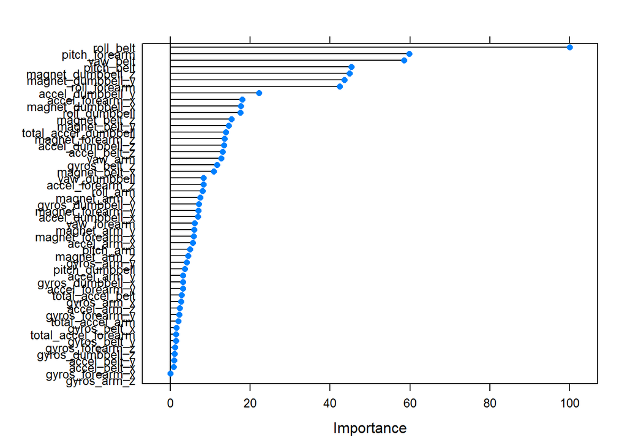

```r
# Plot the importance of each variable used for the Random Forest Classifier model
pmlRF_imp <- varImp(pmlRF)
plot(pmlRF_imp)
```

### Boosting

```r
# Examine all variables in the trainData set to predict the classe variable
pmlGBM <- train(classe ~ ., data=trainData, method="gbm", trControl=ctrl, verbose=FALSE)
# Predict
GBMPred <- predict(pmlGBM, testData)

# Use the testData set to test the results
confusionMatrix(GBMPred, testData$classe)
```

```
## Confusion Matrix and Statistics
##
##           Reference
## Prediction    A    B    C    D    E
##          A 1374   22    0    1    2
##          B   12  902   23    3   10
##          C    6   25  814   22    6
##          D    1    0   16  772   13
##          E    2    0    2    6  870
##
## Overall Statistics
##
##                Accuracy : 0.9649
##                  95% CI : (0.9594, 0.9699)
##     No Information Rate : 0.2845
##     P-Value [Acc > NIR] : < 2.2e-16
##
##                   Kappa : 0.9556
##  Mcnemar's Test P-Value : 0.002129
##
## Statistics by Class:
##
##                      Class: A Class: B Class: C Class: D Class: E
## Sensitivity            0.9849   0.9505   0.9520   0.9602   0.9656
## Specificity            0.9929   0.9879   0.9854   0.9927   0.9975
## Pos Pred Value         0.9821   0.9495   0.9324   0.9626   0.9886
## Neg Pred Value         0.9940   0.9881   0.9898   0.9922   0.9923
## Prevalence             0.2845   0.1935   0.1743   0.1639   0.1837
## Detection Rate         0.2802   0.1839   0.1660   0.1574   0.1774
## Detection Prevalence   0.2853   0.1937   0.1780   0.1635   0.1794
## Balanced Accuracy      0.9889   0.9692   0.9687   0.9764   0.9815
```

```r
# Stop the cluster to release the CPUs.
stopCluster(cluster)
```

## 6. Choose the best model

The Random Forest model is the best fit for the training data. The accuracy metric for the Random Forest model is 0.995 compared to the Boosting model at 0.965, which means that the Random Forest model will be more accurate at predicting the desired class for this data. The estimated out-of-sample error is 0.5%. There will be very little, if any, misclassified samples in the test data considering the high accuracy and low out-of-sample error.

# Prediction

## 7. Apply the prediction model to the test dataset.

```r
pred_test <- predict(pmlRF, pmlTesting)
pred_test
```

```
##  [1] B A B A A E D B A A B C B A E E A B B B
## Levels: A B C D E
```